# Best books by century

Marian Nehrebecki, Aleksander Partyga, Magdalena Sobala

07 June, 2022

## **Century 19**

### Overview

(From the [Goodreads](https://www.goodreads.com)) Goodreads.com is the world’s largest site for readers and book recommendations. The mission of Goodreads is to help people find and share books they love.

The users can rate their favourite books, create lists and share their opinions with their friends. The website also provides extensive information on books from all genres and centuries; it also provides the users with rankings, available by different parameters. The rankings that are of interest to us, are the rating by the century. Below you can find a short summary of each century’s best books.

### A few things we can do on Goodreads

> - See what books our friends are reading.
> - Track the books we are reading, have read, and want to read.
> - Check out our personalized book recommendations. The recommendation engine analyzes 20 billion data points to give suggestions tailored to our literary tastes.
> - Find out if a book is a good fit for us from our community’s reviews.

# Summary of the Best books in Century 19

*Goodreads* provides its users with information on 1562 books from **Century 19** that have been published by Author/Authors from **Jane Austen** to **Guy de Maupassant**.

The best book in Century 19 was **Pride and Prejudice** by **Jane Austen** which gathered *2391 votes*, *236036 scores* and an average rating of *4.8*.

The book can be found under the following link: “https://www.goodreads.com/book/show/1885.Pride_and_Prejudice”

## Visualisations:

### Books that were rated the most times in Century 19

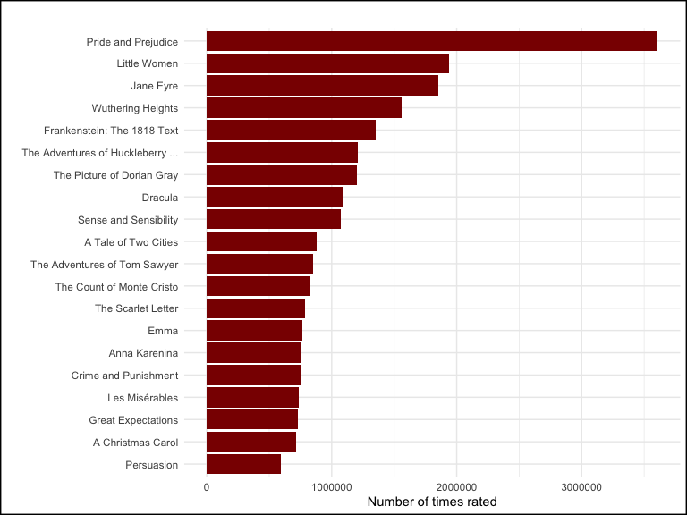

**Summary:**

- The book that was rated the most in Century 19 is **Pride and Prejudice**, and the number of votes is **3609891**.
- The average number of voted for a book from Century 19 is equal **30744.2**.

### Books with the highest scores in Century 19

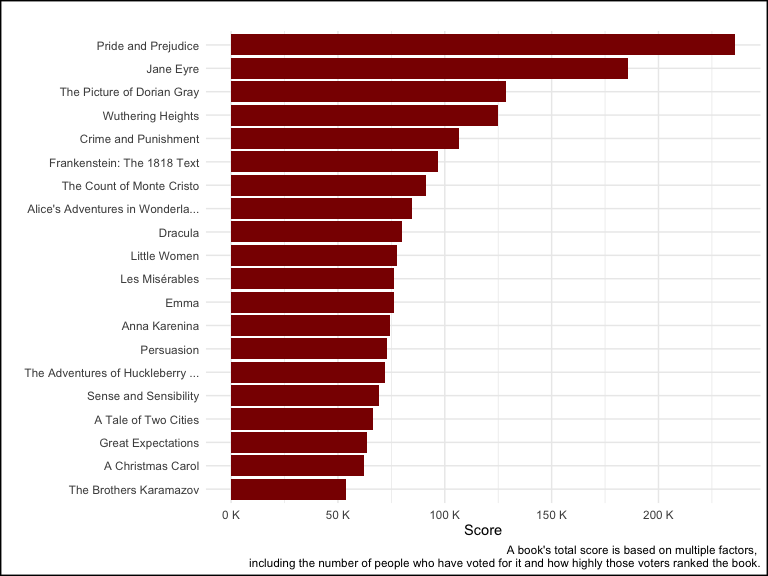

**Summary:**

- The maximum score for a book in Century 19 is **236036** for the book: **Pride and Prejudice**.
- The average score of all books in Century 19 is **2601.5**.
- The minimum score for a book in Century 19 is **1** for the book: **Ποιήματα Άπαντα, Criminals, Idiots, Women, and Minors, The Epicure’s Almanack: Eating and Drinking in Regency London (The Original 1815 Guidebook), Pierre and Jean**.

### Most prolific authors in Century 19

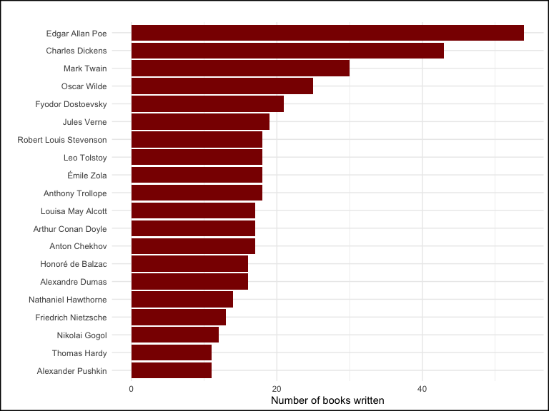

**Summary:**

- The most prolific author in Century 19 is **Edgar Allan Poe**.

## List of books with above average rating in Century 19

| Century | Title | Author | website |
| --- | --- | --- | --- |
| 19th | The Yellow Wallpaper and Other Stories | Charlotte Perkins Gilman | https://www.goodreads.com/book/show/99300.The_Yellow_Wallpaper_and_Other_Stories |
| 19th | Christabel; Kubla Khan, a Vision; The Pains of Sleep | Samuel Taylor Coleridge | https://www.goodreads.com/book/show/9942998-christabel-kubla-khan-a-vision-the-pains-of-sleep |
| 19th | The Malay Archipelago | Alfred Russel Wallace | https://www.goodreads.com/book/show/99629.The_Malay_Archipelago |
| 19th | Горе от ума | Alexander Griboyedov | https://www.goodreads.com/book/show/97390._ |
| 19th | Tales of Belkin and Other Prose Writings | Alexander Pushkin | https://www.goodreads.com/book/show/97385.Tales_of_Belkin_and_Other_Prose_Writings |
| 19th | The Complete Tribune Primer | Eugene Field | https://www.goodreads.com/book/show/971255.The_Complete_Tribune_Primer |
| 19th | What Men Live By | Leo Tolstoy | https://www.goodreads.com/book/show/9825840-what-men-live-by |
| 19th | Early Times In Texas | John Crittenden Duval | https://www.goodreads.com/book/show/9953518-early-times-in-texas |
| 19th | The Idler in France: A Sequel to ‘The Idler in Italy’, Volume II | Marguerite Power Gardiner | https://www.goodreads.com/book/show/9989790-the-idler-in-france |
| 19th | The Queen of Spades and Other Stories | Alexander Pushkin | https://www.goodreads.com/book/show/97381.The_Queen_of_Spades_and_Other_Stories |

### References:

https://www.goodreads.com